# Objective:

# Applying model based on Random forest feature selector

```python
X=X.loc[:,['SL','BP','HR']]
```

```python
from sklearn.model_selection import train_test_split
#splitting the data into four variables , 70% of data will be used to train the model and rest 30% is to test
X_train, X_test, y_train, y_test = train_test_split(X, y, test_size=0.3, random_state=1)
```

```python
print (X.shape)
```

```
(16000, 3)
```

# KNN

```python
#importing KNeighborsClassifier
from sklearn.neighbors import KNeighborsClassifier


model = KNeighborsClassifier(n_neighbors=5)
model.fit(X_train,y_train)
```

```
KNeighborsClassifier(algorithm='auto', leaf_size=30, metric='minkowski',
                     metric_params=None, n_jobs=None, n_neighbors=5, p=2,
                     weights='uniform')
```

```python
predicted= model.predict(X_test) # 0:Overcast, 2:Mild
print(predicted)
```

```
[3 3 5 ... 3 0 3]
```

```python
#Finding the accuracy score
score=round(model.score(X_test,y_test)*100,2)
#Score for predicting the survivor
print (score)
```

```
62.5
```

# Logistic regression

```python
from sklearn.linear_model import LogisticRegression
model=LogisticRegression()
model.fit(X_train,y_train)
```

```
LogisticRegression(C=1.0, class_weight=None, dual=False, fit_intercept=True,
                   intercept_scaling=1, l1_ratio=None, max_iter=100,
                   multi_class='warn', n_jobs=None, penalty='l2',
                   random_state=None, solver='warn', tol=0.0001, verbose=0,
                   warm_start=False)
```

```python
#Predicting the outcome
y_predict = model.predict(X_test)
```

```python
model_score = round(model.score(X_test, y_test)*100,2)
print(model_score)
```

```
31.37
```

# SVM

```python
from sklearn import svm
clf = svm.SVC(gamma=0.025, C=3)
clf.fit(X_train , y_train)

y_pred = clf.predict(X_test)
```

```python
score=round (clf.score(X_test,y_test)*100,2)
print (score)
```

```
32.04
```

# Decision tree classifier

```python
from sklearn.tree import DecisionTreeClassifier
```

```python
dt_model = DecisionTreeClassifier(criterion='entropy',max_depth=5)
dt_model.fit(X_train,y_train)
```

```
DecisionTreeClassifier(class_weight=None, criterion='entropy', max_depth=5,
                       max_features=None, max_leaf_nodes=None,
                       min_impurity_decrease=0.0, min_impurity_split=None,
                       min_samples_leaf=1, min_samples_split=2,
                       min_weight_fraction_leaf=0.0, presort=False,
                       random_state=None, splitter='best')
```

```python
score=round(dt_model.score(X_test,y_test),2)*100
score
```

```
38.0
```

# Random Forest Classifier

```python
from sklearn.ensemble import RandomForestClassifier
print (X.shape)
print (y.shape)
rfcl=RandomForestClassifier(n_estimators=50)
rfcl.fit(X_train,y_train)
```

```
(16000, 3)
(16000,)
```

```
RandomForestClassifier(bootstrap=True, class_weight=None, criterion='gini',
                       max_depth=None, max_features='auto', max_leaf_nodes=None,
                       min_impurity_decrease=0.0, min_impurity_split=None,
                       min_samples_leaf=1, min_samples_split=2,
                       min_weight_fraction_leaf=0.0, n_estimators=50,
                       n_jobs=None, oob_score=False, random_state=None,
                       verbose=0, warm_start=False)
```

```python
test_pred=rfcl.predict(X_test)
rfcl.score(X_test,y_test)
```

```
0.7197916666666667
```

# Random Forest classifier without dimension reduction

```python
df_data_rf=df_data.copy()
X=df_data_rf.drop(['ACTIVITY'],axis=1,inplace=False)
y=df_data_rf['ACTIVITY']
print (X.shape)
print (y.shape)
```

```
(16000, 6)
(16000,)
```

```python
X=X.apply(zscore)
```

```python
from sklearn.model_selection import train_test_split
#splitting the data into four variables , 70% of data will be used to train the model and rest 30% is to test
X_train, X_test, y_train, y_test = train_test_split(X, y, test_size=0.3, random_state=1)
```

```python
from sklearn.ensemble import RandomForestClassifier
rfcl=RandomForestClassifier(n_estimators=50)
rfcl.fit(X_train,y_train)
```

```
RandomForestClassifier(bootstrap=True, class_weight=None, criterion='gini',
                       max_depth=None, max_features='auto', max_leaf_nodes=None,
                       min_impurity_decrease=0.0, min_impurity_split=None,
                       min_samples_leaf=1, min_samples_split=2,
                       min_weight_fraction_leaf=0.0, n_estimators=50,
                       n_jobs=None, oob_score=False, random_state=None,
                       verbose=0, warm_start=False)
```

```python
test_pred=rfcl.predict(X_test)
rfcl.score(X_test,y_test)
```

```
0.7591666666666667
```

# Implementing PCA for dimension reduction

```python
df_data_pca=df_data.copy()
X=df_data_pca.drop(['ACTIVITY'],axis=1,inplace=False)
y=df_data_pca['ACTIVITY']
print (X.shape)
print (y.shape)
```

```
(16000, 6)
(16000,)
```

```python
#Splitting the data
from sklearn.model_selection import train_test_split
#splitting the data into four variables , 70% of data will be used to train the model and rest 30% is to test
X_train, X_test, y_train, y_test = train_test_split(X, y, test_size=0.3, random_state=1)
```

```python
from scipy.stats import zscore
X=X.apply(zscore)
X.head()
```

|  | TIME | SL | EEG | BP | HR | CIRCLUATION |
| --- | --- | --- | --- | --- | --- | --- |
| 0 | -1.180601 | -0.560810 | 0.036977 | -0.938409 | -1.020430 | -0.675907 |
| 1 | -1.306887 | -0.575255 | 0.041123 | -0.793229 | -1.213166 | -0.715884 |
| 2 | -1.170967 | -0.570539 | 0.040052 | -0.253991 | -1.112943 | -0.700367 |
| 3 | -0.505541 | -0.517155 | 0.025572 | -0.668790 | -0.565572 | -0.613574 |
| 4 | -0.727960 | -0.480795 | 0.029844 | 0.554865 | -0.704342 | -0.546507 |

```python
covMatrix = np.cov(X,rowvar=False)
print(covMatrix)
```

```
[[ 1.0000625   0.84472388 -0.04820395  0.44304615  0.97415237  0.87816413]
 [ 0.84472388  1.0000625  -0.05111958  0.40305171  0.859461    0.97779379]
 [-0.04820395 -0.05111958  1.0000625  -0.05018887 -0.050252   -0.05052163]
 [ 0.44304615  0.40305171 -0.05018887  1.0000625   0.4698146   0.42108557]
 [ 0.97415237  0.859461   -0.050252    0.4698146   1.0000625   0.90435199]
 [ 0.87816413  0.97779379 -0.05052163  0.42108557  0.90435199  1.0000625 ]]
```

```python
from sklearn.decomposition import PCA
pca = PCA(n_components=6)
pca.fit(X)
```

```
PCA(copy=True, iterated_power='auto', n_components=6, random_state=None,
    svd_solver='auto', tol=0.0, whiten=False)
```

```python
print(pca.explained_variance_)
```

```
[3.97752382 0.99760692 0.74863768 0.23360111 0.02949372 0.01351177]
```

```python
print(pca.explained_variance_ratio_)
```

```
[0.6628792  0.16625743 0.12476515 0.03893109 0.00491531 0.00225182]
```

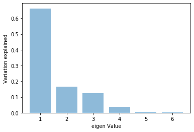

```python
plt.bar(list(range(1,7)),pca.explained_variance_ratio_,alpha=0.5, align='center')
plt.ylabel('Variation explained')
plt.xlabel('eigen Value')
plt.show()
```

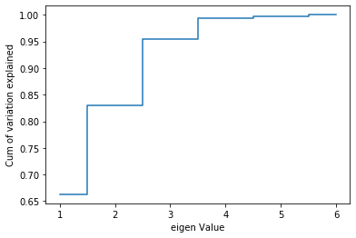

```python
plt.step(list(range(1,7)),np.cumsum(pca.explained_variance_ratio_), where='mid')
plt.ylabel('Cum of variation explained')
plt.xlabel('eigen Value')
plt.show()
```

As we can see from PCA graph is non uniform, so we will not drop any column and will choose 6 as our PC value

```python
pca3 = PCA(n_components=6)
pca3.fit(X)
print(pca3.components_)
print(pca3.explained_variance_ratio_)
Xpca3 = pca3.transform(X)
```

```
[[ 4.77545070e-01  4.72705422e-01 -3.69553483e-02  2.80489919e-01
   4.84431495e-01  4.83514347e-01]
 [-2.93434080e-02 -2.90536236e-02 -9.96094773e-01  6.66185273e-02
  -2.66758364e-02 -3.06663786e-02]
 [-1.09038093e-01 -1.86546832e-01  8.00256126e-02  9.53895830e-01
  -8.40072181e-02 -1.73009849e-01]
 [-5.53176914e-01  5.71701879e-01  4.92889181e-03  7.99191356e-02
  -4.52569573e-01  3.94869197e-01]
 [ 5.93247788e-01  3.90977656e-01  3.22201531e-04  2.05892554e-02
  -5.77707997e-01 -4.01276691e-01]
 [-3.18202339e-01  5.11076496e-01  1.00479107e-03 -1.26149601e-02
   4.67965346e-01 -6.46835663e-01]]
[0.6628792  0.16625743 0.12476515 0.03893109 0.00491531 0.00225182]
```

# Implementing Random forest classifier with PCA

```python
#splitting the data into four variables , 70% of data will be used to train the model and rest 30% is to test
X_train, X_test, y_train, y_test = train_test_split(Xpca3, y, test_size=0.3, random_state=1)
```

```python
from sklearn.ensemble import RandomForestClassifier
rfcl=RandomForestClassifier(n_estimators=50)
rfcl.fit(X_train,y_train)
```

```
RandomForestClassifier(bootstrap=True, class_weight=None, criterion='gini',
                       max_depth=None, max_features='auto', max_leaf_nodes=None,
                       min_impurity_decrease=0.0, min_impurity_split=None,
                       min_samples_leaf=1, min_samples_split=2,
                       min_weight_fraction_leaf=0.0, n_estimators=50,
                       n_jobs=None, oob_score=False, random_state=None,
                       verbose=0, warm_start=False)
```

```python
test_pred=rfcl.predict(X_test)
rfcl.score(X_test,y_test)
```

```
0.6789583333333333
```

# Implementing KNN with PCA

```python
#importing KNeighborsClassifier
from sklearn.neighbors import KNeighborsClassifier


model = KNeighborsClassifier(n_neighbors=5)
model.fit(X_train,y_train)
```

```
KNeighborsClassifier(algorithm='auto', leaf_size=30, metric='minkowski',
                     metric_params=None, n_jobs=None, n_neighbors=5, p=2,
                     weights='uniform')
```

```python
predicted= model.predict(X_test) # 0:Overcast, 2:Mild
print(predicted)
```

```
[3 0 5 ... 3 0 3]
```

```python
score=round(model.score(X_test,y_test)*100,2)
#Score for predicting the survivor
print (score)
```

```
63.29
```

# Bagging

Bootstrap Aggregation or bagging involves taking multiple samples from your training dataset (with replacement) and training a model for each sample.

The final output prediction is averaged across the predictions of all of the sub-models.

```python
# Bagging

from sklearn.ensemble import BaggingClassifier
bgcl=BaggingClassifier(n_estimators=50,max_samples=.8,oob_score=True)
bgcl=bgcl.fit(X_train,y_train)
print (bgcl.oob_score_)
```

```
0.6647321428571429
```

```python
#Creating a bagging function to be used with other models later on

def bagging_score(model_object):
    from sklearn.ensemble import BaggingClassifier
    bgcl=BaggingClassifier(base_estimator=model_object,n_estimators=5,max_samples=.8,oob_score=True)
    bgcl=bgcl.fit(X_train,y_train)
    return (round((bgcl.oob_score_)*100,2))
```

# BOOSTING

Boosting ensemble algorithms creates a sequence of models that attempt to correct the mistakes of the models before them in the sequence.

Once created, the models make predictions which may be weighted by their demonstrated accuracy and the results are combined to create a final output prediction.

The two most common boosting ensemble machine learning algorithms are:

AdaBoost Stochastic Gradient Boosting

```python
dt_model = DecisionTreeClassifier(criterion='entropy',max_depth=5)
dt_model.fit(X_train,y_train)
score=round(dt_model.score(X_test,y_test),2)*100
score
```

```
39.0
```

```python
#Boosting
#Ada boosting
from sklearn.ensemble import AdaBoostClassifier
abcl=AdaBoostClassifier(base_estimator=dt_model,n_estimators=50)
abcl.fit(X_train,y_train)
```

```
AdaBoostClassifier(algorithm='SAMME.R',
                   base_estimator=DecisionTreeClassifier(class_weight=None,
                                                         criterion='entropy',
                                                         max_depth=5,
                                                         max_features=None,
                                                         max_leaf_nodes=None,
                                                         min_impurity_decrease=0.0,
                                                         min_impurity_split=None,
                                                         min_samples_leaf=1,
                                                         min_samples_split=2,
                                                         min_weight_fraction_leaf=0.0,
                                                         presort=False,
                                                         random_state=None,
                                                         splitter='best'),
                   learning_rate=1.0, n_estimators=50, random_state=None)
```

```python
#making function for ada boosting to be used by other base_estimators later on
def ada_boosting_score(model):
    from sklearn.ensemble import AdaBoostClassifier
    abcl=AdaBoostClassifier(base_estimator=model,n_estimators=50)
    abcl.fit(X_train,y_train)
    abcl_predict=abcl.predict(X_test)
    score=round(abdcl.score(X_test,y_test)*100,2)
    return score
```

```python
abcl_pred=abcl.predict(X_test)
abcl.score(X_test,y_test)
```

```
0.41
```

```python
#Gradient boost
#Gradient boost
from sklearn.ensemble import GradientBoostingClassifier
gbcl=GradientBoostingClassifier(n_estimators=50,learning_rate=.08,max_depth=5)
gbcl.fit(X_train,y_train)
```

```
GradientBoostingClassifier(criterion='friedman_mse', init=None,
                           learning_rate=0.08, loss='deviance', max_depth=5,
                           max_features=None, max_leaf_nodes=None,
                           min_impurity_decrease=0.0, min_impurity_split=None,
                           min_samples_leaf=1, min_samples_split=2,
                           min_weight_fraction_leaf=0.0, n_estimators=50,
                           n_iter_no_change=None, presort='auto',
                           random_state=None, subsample=1.0, tol=0.0001,
                           validation_fraction=0.1, verbose=0,
                           warm_start=False)
```

```python
test_pred=gbcl.predict(X_test)
gbcl.score(X_test,y_test)
```

```
0.598125
```

# Bagging with Random Forest

```python
rfcl_bag=RandomForestClassifier(n_estimators=50)
```

```python
model_score=bagging_score(rfcl_bag)
print (model_score)
```

```
64.06
```

# Bagging with KNN

```python
knn_model = KNeighborsClassifier(n_neighbors=5)
```

```python
model_score=bagging_score(knn_model)
print (model_score)
```

```
59.54
```

# Remarks till now

Random forest classifier without dimension reduction is seems to be best choice till now